# Part II - Ford GoBike System Data Explanation:

## by Mamdouh Ali

## Investigation Overview

In this investigation, I wanted to look at the characteristics of trip data that could be used to predict their duration. The main focus was on the five: age, duration, user type, and gender.

## Dataset Overview

The data consisted of duration_sec and attributes of approximately 174,952. The attributes included the five, as well as additional measurements such as start station name, start station latitude, and start station longitude.

## Distribution of Trip Durations

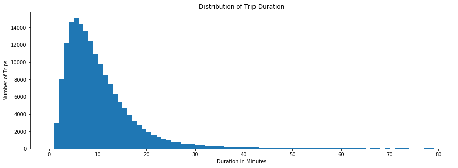

## Distribution of User Age

In the case of age, you can see that the distribution is more concentrated between 20 to 40 years old.

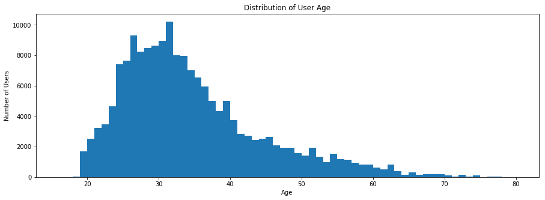

## User Type vs. Gender

Males and subscribers are with more trips than females and customers.

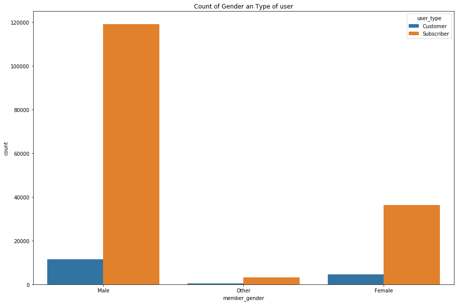

## Trip Duration vs. Age

By looking at the chart below, we can see that most frequent users aged between 20 and 45. As remark, duration is registered by younger members.

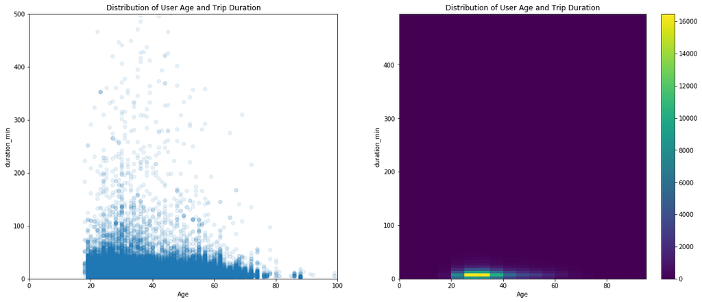